# Reproducible Research: Peer Assessment 1

Bachir

24 mars 2018

## Loading and preprocessing the data

### 1. Load the data

```r
fileUrl <- "https://d396qusza40orc.cloudfront.net/repdata%2Fdata%2Factivity.zip"
download.file(fileUrl,destfile="./Factivity.zip",method="auto")
unzip(zipfile = "Factivity.zip")
unlink("Factivity.zip")

### Read data file
library(readr)
activity1 <- read_csv("activity.csv")
head(activity1)
```

```
## # A tibble: 6 x 3
##   steps date       interval
##   <int> <date>        <int>
## 1    NA 2012-10-01        0
## 2    NA 2012-10-01        5
## 3    NA 2012-10-01       10
## 4    NA 2012-10-01       15
## 5    NA 2012-10-01       20
## 6    NA 2012-10-01       25
```

### 2. Process the data

```r
library(plyr)
activity1$date<- as.Date(activity1$date, format="%Y-%m-%d")
```

## What is mean total number of steps taken per day?

### 1. Calculate the total number of steps taken per day

```r
stepsday <- with(activity1, aggregate(steps, list(date), sum, na.rm = TRUE))
names(stepsday) <- c("date", "steps")
```

### 2. Make a histogram of the total number of steps taken each day

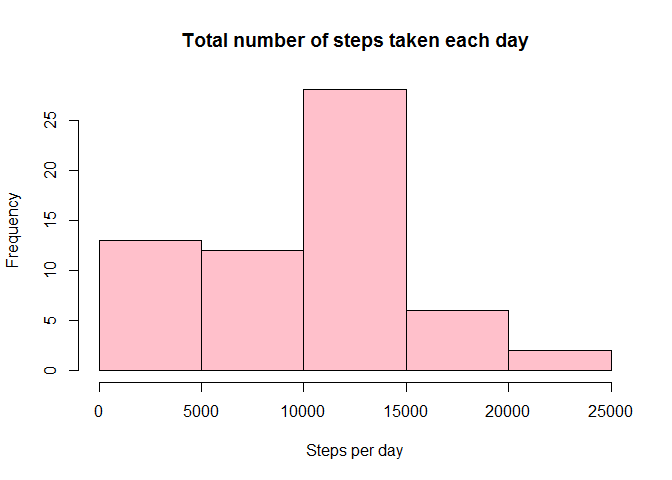

```r
hist(stepsday$steps, col = "pink",
     xlab = "Steps per day", main = "Total number of steps taken each day")
```

### 3. Calculate and report the mean and median of the total number of steps taken per day

```r
mean(stepsday$steps, na.rm = TRUE)
```

```
## [1] 9354.23
```

```r
median(stepsday$steps, na.rm = TRUE)
```

```
## [1] 10395
```

## What is the average daily activity pattern?

### 1. Calculate the average number of steps taken per 5-minute interval

```r
stepsint <- with(activity1, aggregate(steps, list(interval), mean, na.rm = TRUE))
names(stepsint) <- c("interval", "steps")
```

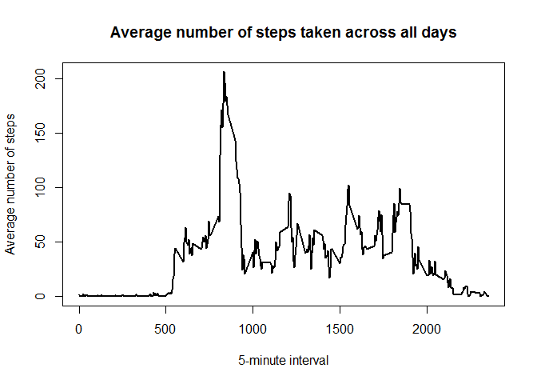

```r
with(stepsint, plot(interval, steps, type = "l", lwd = 2,
                    xlab = "5-minute interval", ylab = "Average number of steps",
                    main = "Average number of steps taken across all days"))
```

### 3. Which 5-minute interval, on average across all the days in the dataset, contains the maximum number of steps?

```r
stepsint$interval[which.max(stepsint$steps)]
```

```
## [1] 835
```

## Imputing missing values

### 1. Calculate and report the total number of missing values in the dataset

```r
sum(is.na(activity1$steps))
```

```
## [1] 2304
```

### 2. Devise a strategy for filling in all of the missing values in the dataset

*The strategy does not need to be sophisticated. We use the mean for steps.*

### 3. Create a new dataset that is equal to the original dataset but with the missing data filled in.

```r
activity2 <- activity1
NA.position <- which(is.na(activity2$steps))
pos <-mean(stepsint$steps,na.rm = TRUE)
for (i in 1:length(NA.position)) {
  activity2[NA.position[i],1] <- pos
}
head(activity2)
```

```
## # A tibble: 6 x 3
##   steps date       interval
##   <dbl> <date>        <int>
## 1  37.4 2012-10-01        0
## 2  37.4 2012-10-01        5
## 3  37.4 2012-10-01       10
## 4  37.4 2012-10-01       15
## 5  37.4 2012-10-01       20
## 6  37.4 2012-10-01       25
```

### 4. Make a histogram of the total number of steps taken each day and Calculate and report the mean and median total number of steps taken per day.

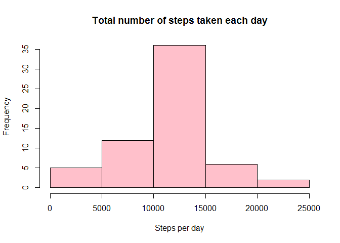

```r
stepsday2 <- with(activity2, aggregate(steps, list(date), sum))
names(stepsday2) <- c("date", "steps")

hist(stepsday2$steps, col = "pink",
     xlab = "Steps per day", main = "Total number of steps taken each day")
```

*Mean and Median*

```r
mean(stepsday2$steps)
```

```
## [1] 10766.19
```

```r
median(stepsday2$steps)
```

```
## [1] 10766.19
```

#### Do these values differ from the estimates from the first part of the assignment?

```r
a <- mean(stepsday2$steps) - mean(stepsday$steps, na.rm = TRUE)
a
```

```
## [1] 1411.959
```

```r
median(stepsday2$steps) - median(stepsday$steps, na.rm = TRUE)
```

```
## [1] 371.1887
```

#### What is the impact of imputing missing data on the estimates of the total daily number of steps?

*The estimates of the total daily number of steps increase by 1411.959171*

## Are there differences in activity patterns between weekdays and weekends?

```r
activity2 <- mutate(activity2, week = ifelse(weekdays(activity2$date) == "samedi" |
                                               weekdays(activity2$date) == "dimanche", "weekend", "weekday"))
activity2$week <- as.factor(activity2$week)
```

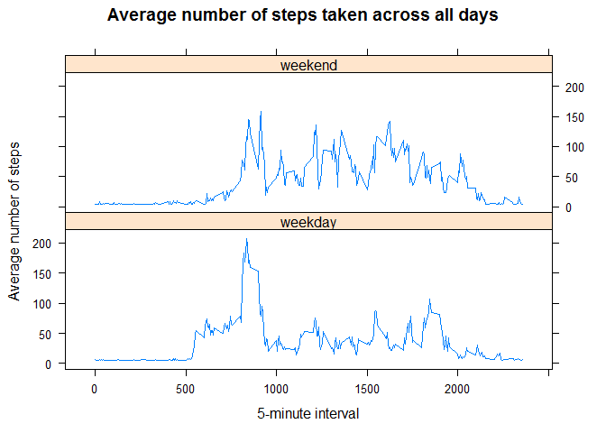

```r
stepsint3 <- with(activity2, aggregate(steps, list(interval, week), mean))
names(stepsint3) <- c("interval", "week", "steps")

library(lattice)
xyplot(steps ~ interval | week, data = stepsint3, type="l",  layout = c(1,2),
       main="Average number of steps taken across all days",
       ylab="Average number of steps", xlab="5-minute interval")
```